# Reclaiming Agency

Educators as Architects of AI-Enhanced Learning Architectures

Bodong Chen

cbd@upenn.edu • bchen.net

Associate Professor in Learning Sciences and Technologies  
University of Pennsylvania Graduate School of Education  
**Language Educator Symposium 2025**

# Spring 2023

My first AI policy

Here is **Alex**

[interactive chart not shown]

I *wasn’t* answering a simple question.

[figure not shown]

“Can I use **X** for **Y**?”

These are questions on **the architecture for learning**.

Source: Edtech Insider

# Revealing the Architecture

[figure not shown]

## Shearing Layers of Change

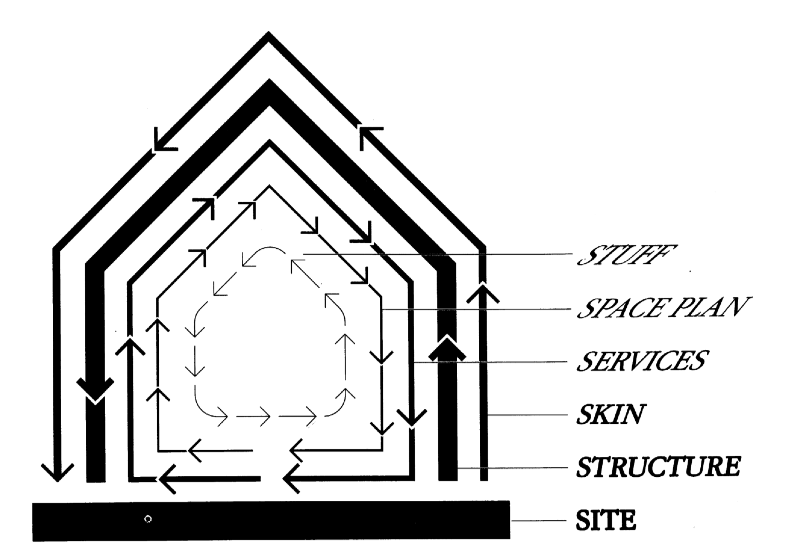

Each layer changes at different pace, and acts as a platform for the layer above it.

- **Stuff** (days-months) Furniture, books
- **Space Plan** (3-30 yrs) Interior layout
- **Services** (7-15 yrs) Wiring, plumbing
- **Skin** (20 yrs) Exterior surfaces
- **Structure** (30-300 yrs) Load-bearing
- **Site** (eternal) Geographical setting

“The quick processes provide originality and challenge, the slow provide continuity and constraint.” — Brand (1994, p. 17)

## Learning Architectures

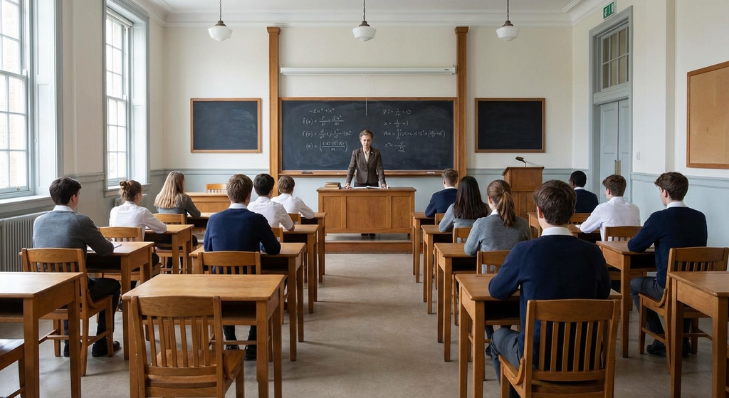

Classroom A

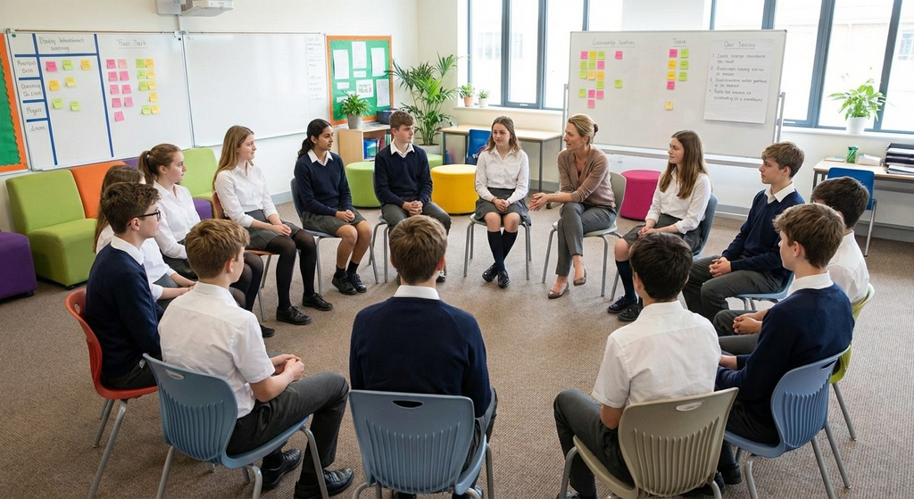

Classroom B

## Layers in Learning Architectures

Alex: “Can I use ChatGPT to outline my paper?”

**Buildings**

| Stuff |
| --- |
| Space Plan |
| Services |
| Skin |
| Structure |
| Site |

**Classrooms**

| **Practices** (days): Activities, interactions |
| --- |
| **Plans** (wks-mons): Lessons, assignments |
| **Protocols** (mons-yrs): Norms, routines |
| **Pedagogies** (yrs): Approaches, relations |
| **Principles** (decades): Foundations, lens |
| **Philosophy** (centuries): Epistemologies |

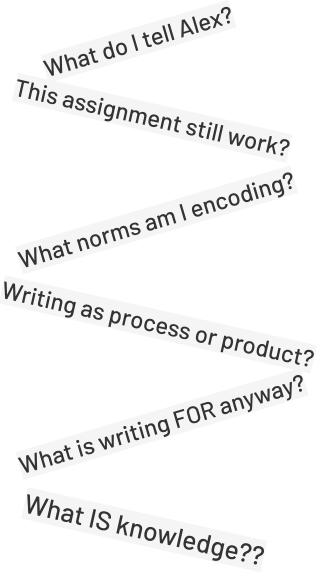

## Principles of *Thinking Like an Architect*

**1. Recognize the Layers**  
What layer am I actually working at?

- **Locate which layer a problem or decision primarily affects.** A student question might seem like a practice issue, but may be more relevant to the pedagogy layer.
- **Look deeper—surface questions often have slow-layer reasons.** A fast-layer question may stem from ambiguity in the slow layers below.

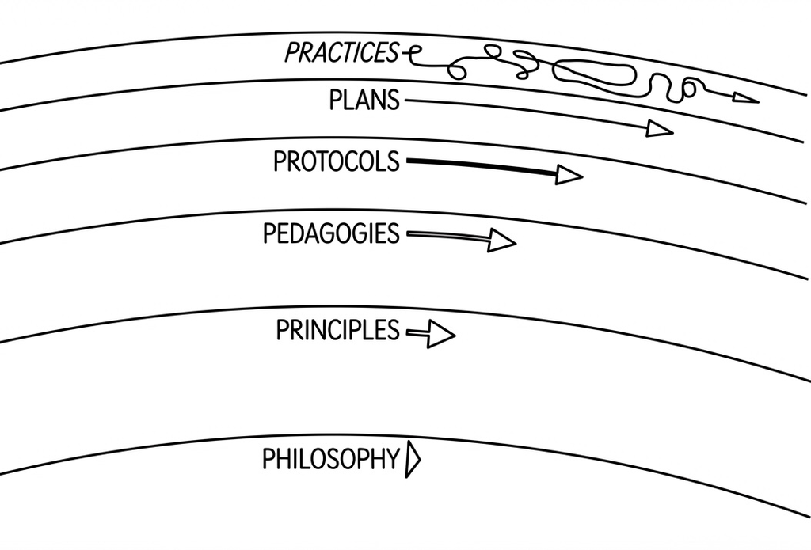

Figure adapted from [Brand (2018)](https://longnow.org/ideas/pace-layers/)

## Principles of *Thinking Like an Architect*

**2. Work Across the Layers and with Tensions**  
What other layers should I also consider?

- **Fast learns, slow remembers. Fast gets attention, slow has power.** Practices experiment and adapt; principles and philosophy provide stability and wisdom
- **Tensions arise between layers during sudden change.** New technologies can create ripple effect across layers.

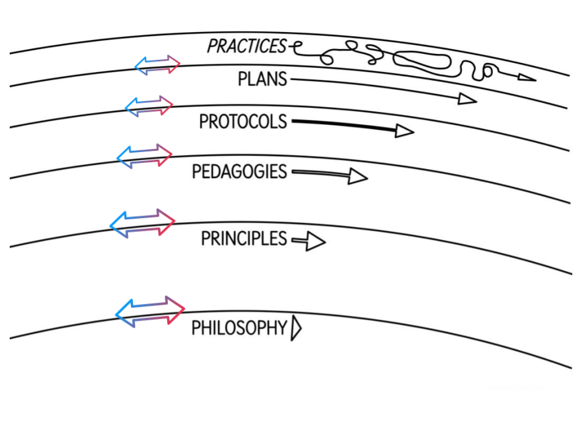

# **Human Experience** in the Architecture

“**Architecture is a mediation between the world and our minds.** Good architecture tells us something about the world… and finally, it tells us who we are.”

— Juhani Pallasmaa

## Dwelling Precedes Building (Martin Heidegger)

**be** → **dwell** (*wohnen*) → **build**

- **Dwelling** = being genuinely “at home”; not just occupying space
- **Building should serve dwelling**, not determine it

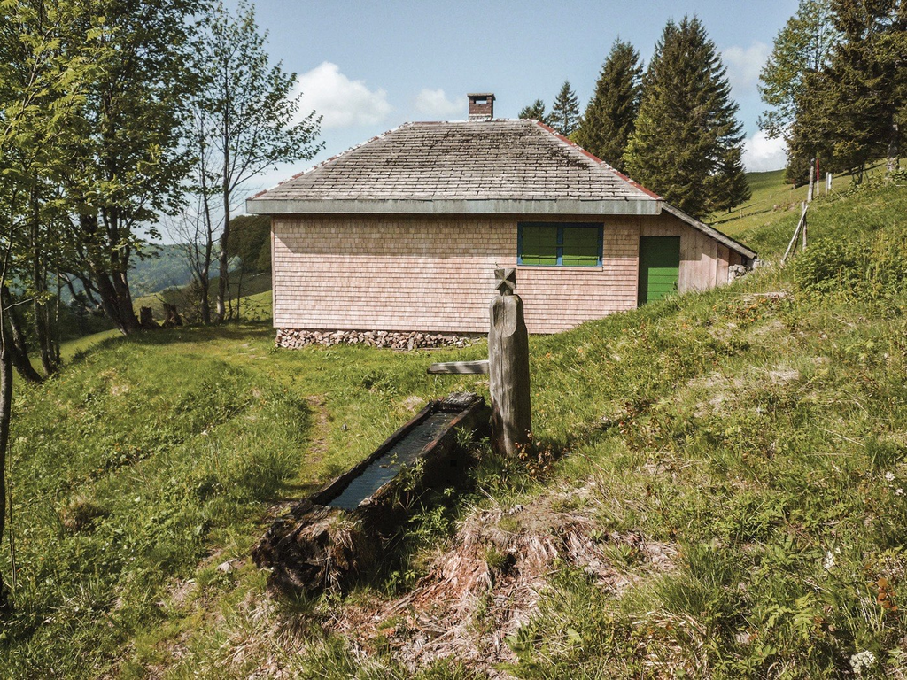

Photo: [Heidegger’s hut](https://thinkingplace.org/heidegger/)

## Space is a social product (Henri Lefebvre)

**A triad that’s always in tension:**

- **Conceived space**: Expert-designed plans
- **Perceived space**: How people actually use it
- **Lived space**: Emotional, symbolic experience

**The political problem:** Conceived space dominates—expert abstractions override lived reality

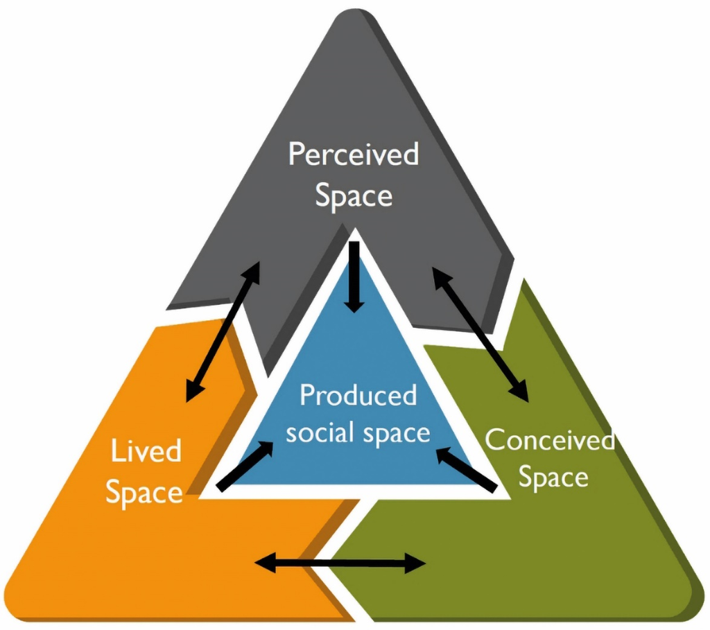

Image source: [Michon (2024)](https://journals.openedition.org/lerhistoria/13079?lang=en)

“The task of architecture is to **defend the autonomy of human experience**, not to **condition, dominate or dictate**.”

— Juhani Pallasmaa

## Principles of *Thinking Like an Architect*

**3. Begin with Dwelling, Not Building**  
*How do learners actually dwell in the space?*

- **Ask: “How do we dwell?”**, not “What can we build?”
- **Start with lived experience**, not technological capability.
- **Let perceived and lived space inform design**: Resist expert abstractions dominating learner reality and experience

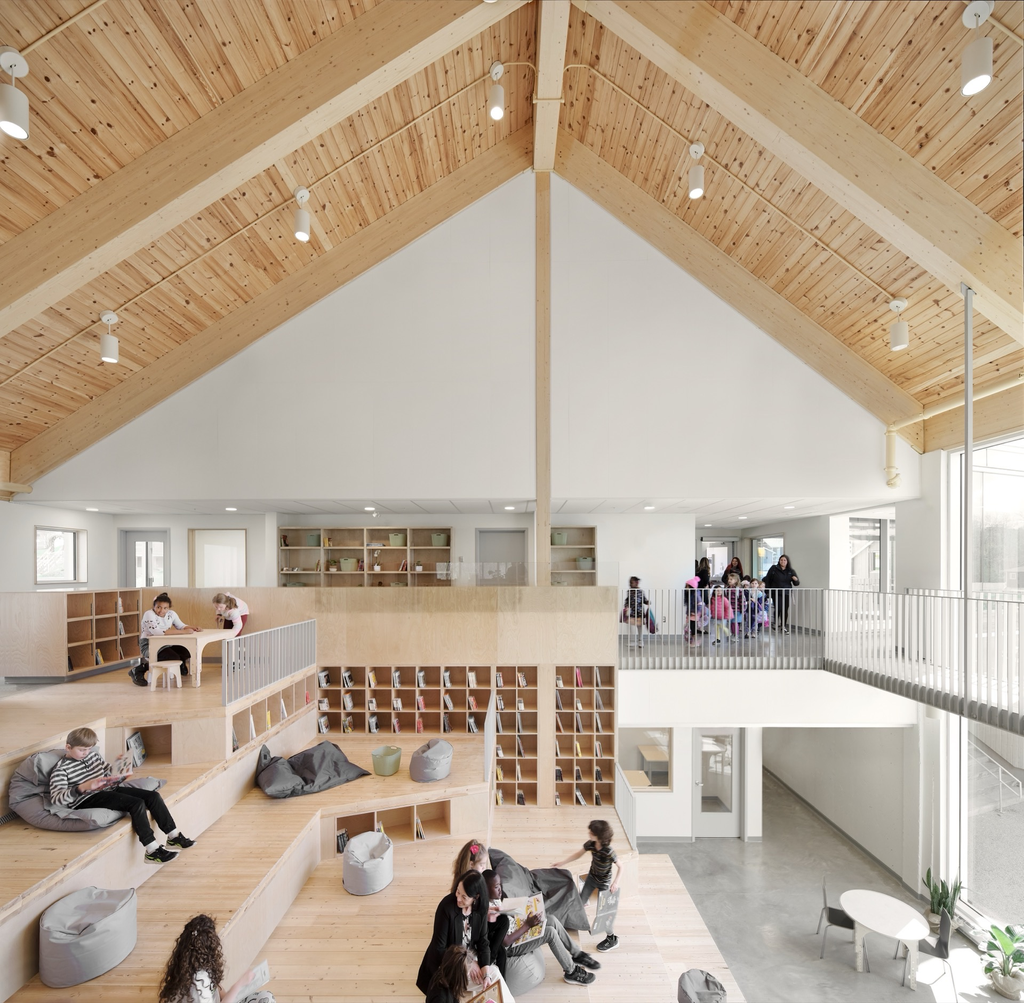

Photo source: [Architizer](https://architizer.com/blog/practice/details/education-architecture-changing-views-childhood/)

## Principles of *Thinking Like an Architect*

**4. Mediate, Don’t Dominate**  
*Does this defend autonomy or impose control?*

- **Center human autonomy**: They navigate; algorithms support
- **Connect learners to different worlds**, without prescribing the journey or shying away from struggle
- **Resist conceived-space domination**: Don’t let institutional metrics dictate real learning

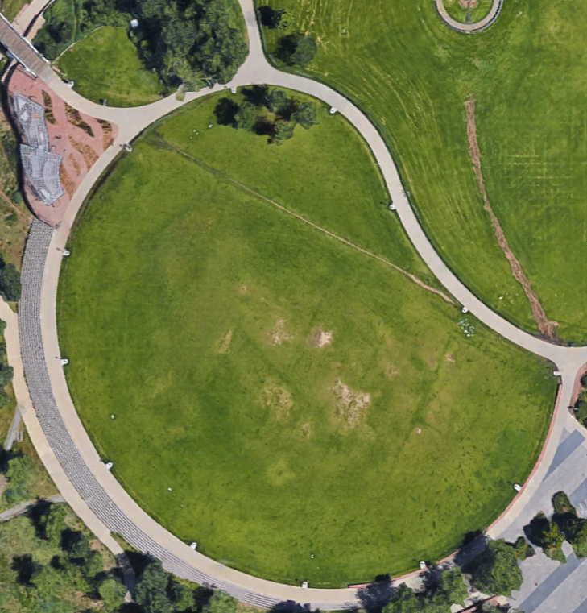

Photo source: [StreetBlog](https://denver.streetsblog.org/2016/08/05/parkfail-dont-even-think-about-walking-straight-through-commons-park/)

## A Tale of Two AI Apps

**Language Tutor**: *“Complete exercises. Here is your badge.”*

- Conceived space dominates: expert metrics override lived experience
- Fragments language from culture and identity
- Corrects every “error”—little space for struggle
- Placeless, generic—no belonging or attachment

Learners **occupy**, never truly dwell. App **dictates** and conditions behavior.

**Language Pathfinder**: *“What worlds do you want to explore?”*

- Lived experience informs design: goals, culture, identity matter
- Integrates language with authentic communication contexts
- Honors struggle and situated perspectives as essential to learning
- Enables attachment, memory, belonging—a place to return to

Learners **dwell**, feeling “at home.” App **mediates** and promote autonomy.

# Reclaiming Agency as Educators

The best AI tools for learning **have not been created yet**

e.g., cultural bias (Tao et al., 2024), gender bias (Du et al., 2025), pedagogical bias (Chen et al., 2025)

## Action 1. Think Like Architects, Not Users

| **Principles** | *Users* ask | *Architects* ask |
| --- | --- | --- |
| **Layers** | Does this tool work? | What layer am I working at—*Practices* or *Principles*? |
| **Tensions** | Can I use this for grading? | How does this change affect slow layers? |
| **Dwelling** | Will it help students? | What is authentic learning and does this tool serve it? |
| **Autonomy** | Should I allow this tool to be used? | How does this tool mediate relations? Does it dominate or defend student autonomy? |

Moving from **thinking**  
and **critiquing**  
to **building**

## Action 2. Be an Educator–Builder

*The promise: AI enables educators to build, with taste*

- **Express professional craft in new mediums**: Create tools that embody your pedagogical expertise—what you know about learning that tool engineers don’t
- **Build with architectural intention**: Respect layers (fast/slow), dwelling (authenticity), and autonomy (mediate, don’t dominate)
- **Build with purpose, aesthetics, and care**: Enable learning experiences that are not just functional, but meaningful, beautiful, worthy of attachment

## Example: ChatLab

An app I built for my learning theories class

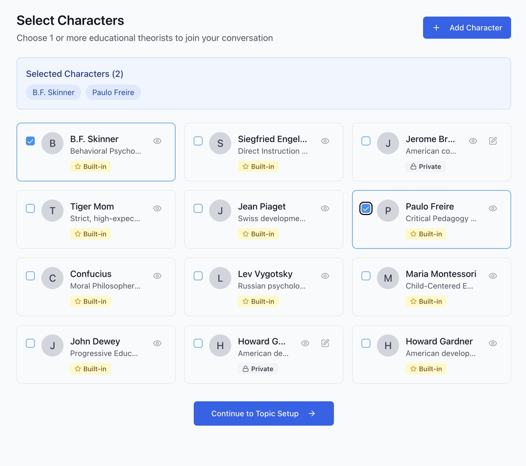

Students set topic, orchestrate, analyze, and reflect

**Principles in Action:**

- Learning is multifaceted, requiring dialogue and reflection [**Dwelling**]
- ChatLab facilitate connections with theorists [**Mediate**]
- Students set the topic, ‘invite’ voices, and critically analyze and reflect [**Autonomy**]

**Results:** New practices and protocols, but same pedagogy. Surprising connections by students that deepen understanding.

## Action 3. Maintain and refresh professional identity

*For teacher educators, department chairs, professional leaders*

- **Position educators as architects**: Support educators building learning architecture that embody their professional expertise
- **Innovate practices, preserve principles**: Revamp fast layers (practices, tools) without mindlessly bulldozing slow layers (pedagogical values)
- **Build collective knowledge**: Create repositories of exemplars, frameworks, workflows, infrastructures
- **Change with intention**: Adapt responsibly—be aware but critical of fashion, protect foundations, evolve with purpose

## Example: CraftPad

An AI-embedded canvas for teachers to design knowledge-building lessons

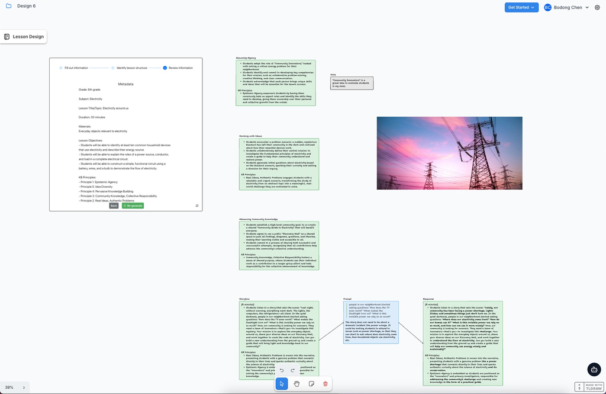

**Principles in Action:**

- Teachers craft designs based on pedagogical principles and their goals [**Autonomy**]
- Teacher design is iterative [**Dwelling**]
- Teachers and AI interact in many ways on the canvas that foreground their design [**Mediate**]
- Built-in AI coach for continual reflection [**Dwelling**]

**Result:** Teachers designing *with* AI iteratively, not consuming AI-generated content. Professional agency is nurtured.

Thanks to Wonder Lab members  
**Jiayu Cheng, Vivian Leung, Yue Zhao**

## Reclaim Agency: Educators as Architects

**Four Principles**

1. **Recognize the Layers**
2. **Work Across Layers and With Tensions**
3. **Begin with Dwelling, Not Building**
4. **Mediate, Don’t Dominate**

**Three Actions**

1. **Think like architects**—not users
2. **Be educator-builders**—build with taste
3. **Maintain and refresh professional identity**—adapt responsibly

Let’s reclaim the agency to **shape the learning architecture** for generations to come

**Bodong Chen**  
cbd@upenn.edu • bchen.net  
[penn-wonderlab.github.io](https://penn-wonderlab.github.io/)